# Lecture 6. Monte-Carlo Algorithms:

# General Concepts and Direct Sampling

This notebook complements the resepctive lecture notes.

## Monte-Carlo Introduction

There are two flavors of MC algorithms: Direct Sampling MC and Markov Chain MC.

Let us illustrate both on the simple example of the 'pebble' game - calculating the value of $\pi$ by sampling interior of a circle.

### 1. Direct-Sampling by Rejection [pebble game]

Main feature of the DS MC - memorylessness - new sample is chosen completely independently from the previous one.

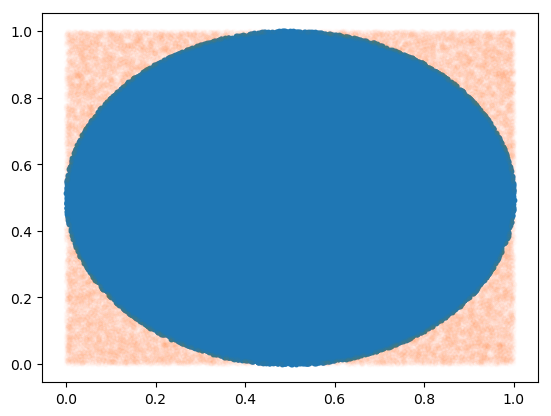

```
3.15248
```

```julia
using PyPlot

N=100000                             # number of dots/samples

x_in = Float64[]
y_in = Float64[]
x_out = Float64[]
y_out = Float64[]

count = 0

for i in 1:N
    x = rand()
    y = rand()                       # generate samples uniformly dstributed within a square
    if (x-0.5)^2+(y-0.5)^2 < 0.25    # accept if the sample within the sphere
        count = count + 1
        push!(x_in, x)               # push!(x_in,x) ands x to the end of x_in
        push!(y_in, y)
        else                         # reject otherwise
        push!(x_out, x)
        push!(y_out, y)
    end
end

scatter(x_in, y_in, s=10)
scatter(x_out, y_out, s=10,alpha = 0.01)

pi = 4*count/N                      # estimation for \pi
```

### 2. MCMC [pebble game]

MCMC keeps the memory - the next sample is chosen based on the current sample.

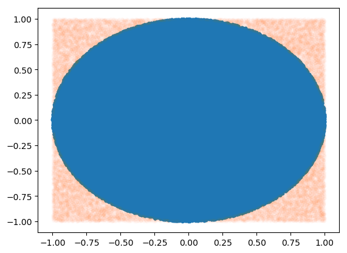

```
3.1476
```

```julia
using Distributions
using PyPlot

N=100000                                # number of steps/samples
delta = 1                               # parameter related to the step size

x=1.0 # Initial coordinates
y=1.0

count = 0

d = Uniform(-delta,delta)

x_in = Float64[]                        # preparing data for the scatter plot
y_in = Float64[]
x_out = Float64[]
y_out = Float64[]

for i in 1:N

    dx = rand(d,1)
    dy = rand(d,1)
    x = x + dx[1]
    y = y + dy[1]

                                        # periodic boundary conditions for the walker
    if x>1
        x = x-2
    end
    if x<-1
        x = x+2
    end
    if y>1
        y = y-2
    end
    if y<-1
        y = y+2
    end

    if x^2 + y^2 < 1
        count = count + 1
        push!(x_in, x)
        push!(y_in, y)
    else
        push!(x_out, x)
        push!(y_out, y)
    end
end

scatter(x_in, y_in, s=10, )
scatter(x_out, y_out, s=10, alpha=0.01)

pi = 4*count/N
```

## Monte-Carlo Direct Sampling

### 1. Direct Sampling by Mapping

The function rand() generates the random variable $x$, uniformly distributed at $[0,1)$ interval, $x\sim U([0,1))$. Our goal is to utilize random $x$ to generate random $y$ distributed exponentially within $[0, \infty)$, $y\sim \exp(-y)$.

One simple way to achive the goal is to relate the two variables (map $x$ to $y$) through explicit formula: $\exp(-y)=x$. (Indeed, $\exp(-y)dy=-dx$.)

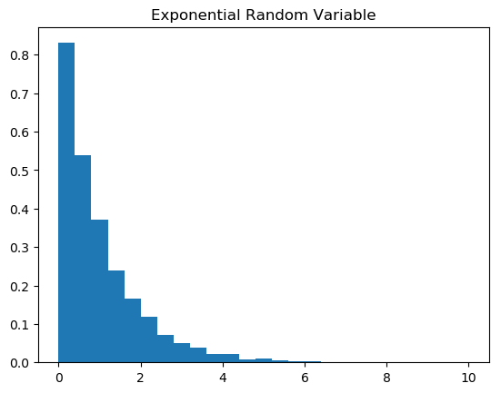

```
PyObject <matplotlib.text.Text object at 0x7f9658b4da50>
```

```julia
using PyPlot
N=10000
x = rand(N)
y = -log(x)
PyPlot.plt[:hist](y, bins = 25, range=(0,10), normed=1)
PyPlot.title("Exponential Random Variable")
```

Another example of DS MS by mapping, **Box Muller Algotithm**, which is a smart way to map two-dimensional random variable distributed uniformly within a box to the two-dimensional Gaussian (normal) random variable:

$$ \int_{-\infty}^{\infty} \dfrac{dx dy}{2 \pi} e^{-(x^2+y^2)/2} = \int_0^{2\pi} \frac{d \varphi}{2 \pi} \int_0^{\infty} r dr \, e^{-r^2/2} = \int_0^{2\pi} \frac{d \varphi}{2 \pi} \int_0^{\infty} d z \, e^{-z} = \int_0^{1} d \theta \int_0^{1} d \psi = 1.$$

Thus, the deisred mapping is $(\psi,\theta)\to (x,y)$, where $x = \sqrt{-2 \log \psi} \cos (2 \pi \Theta)$ and $y = \sqrt{-2 \log \psi} \sin (2 \pi \theta)$.

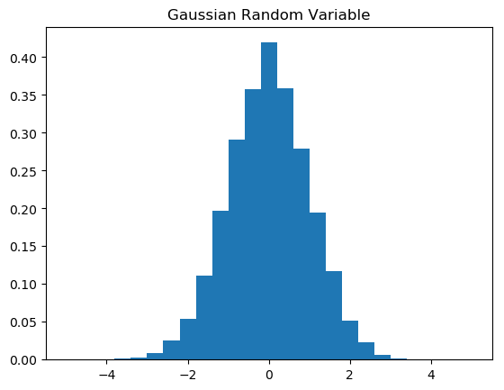

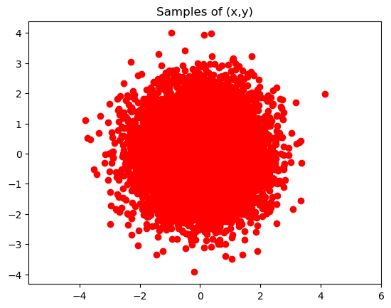

```
PyObject <matplotlib.text.Text object at 0x7f9658700950>
```

```julia
using PyPlot

N=10000

psi = rand(N)
theta = rand(N)

r = sqrt(-2.*log(psi))
x = r.*cospi(2.*theta)
y = r.*sinpi(2.*theta)

PyPlot.figure(1)
PyPlot.plt[:hist](x, bins = 25, range=(-5,5), normed=1)
PyPlot.title("Gaussian Random Variable")

PyPlot.figure(2)
PyPlot.axis("equal")
PyPlot.plot(x,y,"ro")
PyPlot.title("Samples of (x,y)")
```

### 2. Direct Sampling by Rejection (second time)

Let us now show how to get positive Gaussian (normal) random variable from an exponential random variable through rejection.

- First, one samples from the exponential distribution: $x\sim \rho(x)=\begin{cases}e^{-x} & x>0,\\ 0 &\text{otherwise}\end{cases}$
- Second, aiming to get a sample from the positive half of Gaussian, $x\sim \rho_0(x)=\begin{cases}\sqrt{2/\pi}\exp(-x^2/2) & x>0,\\ 0 &\text{otherwise}\end{cases}$, one accepts the generated sample with the probability $$ p(x)=\frac{1}{M}\sqrt{2/\pi}\exp(x-x^2/2)$$ where $M$ is a constant which should be larger than, $\max(\rho (x) / \rho_0(x)) = \sqrt{2/\pi} \, e^{1/2} \approx 1.32$, to guarantee that $p(x)\leq 1$ for all $x>0$.

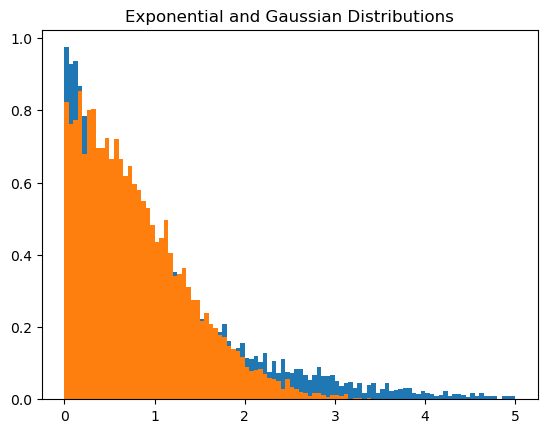

```
0.4023
```

```julia
using PyPlot
using Distributions

function rho_0_pdf(x) # initial=exponential distribution
    return exp(-x)
end

function rho_pdf(x) # desired=Gaussian distribution
    return (2/sqrt(2*pi))*exp(-x^2/2)
end

rho0 = Exponential() # initial distribution
M = 1.4            # parameter M
N = 10000
i = 1
reject=0
rand_var = Float64[] # Generated Random Variable

while i<N
    sample = rand(rho0, 1)
    unif = rand()
    if unif[1] < rho_pdf(sample[1])/(rho_0_pdf(sample[1])*M)
        push!(rand_var, sample[1])
        i=i+1
    else
        reject=reject+1
    end
end

epsilon_values = rand(rho0, N)

PyPlot.plt[:hist](epsilon_values, bins = 100, range=(0,5), normed=1)
PyPlot.plt[:hist](rand_var, bins = 100, range=(0,5), normed=1)
PyPlot.title("Exponential and Gaussian Distributions")

reject=reject/N   # rejection probability
```

Note that the rejection algorithm has the advantage that it can be applied even when the probability densities are known only upto a multiplicative constant. (We will discuss issues related to this constant, also called in the multivariate case the partition function, a number of times later in the course.)

### 3. Importance Sampling

As we saw MC is useful for computing sums/integrals/expectations. Suppose we want to compute an expectation of a function, $f(x)$, over the distribution, $\rho(x)$, i.e. $\int dx \rho(x) f(x)$, in the regime where $f(x)$ and $\rho_0(x)$ are concentrated around very different $x$. In this case overlap of $f$ and $\rho_0(x)$ is small and as a result a lot of MC samples will be 'wasted'.

Importance Sampling is the method which helps to fix the small-overlap problem. It is based on adjusting the distribution function from $\rho(x)$ to $\rho_0(x)$ and then utilizing the following obvious formula

$$ \mathbb{E}_{\rho}[f(x)]=\int dx \rho(x) f(x)=\int dx \rho_0(x) \frac{f(x)\rho(x)}{\rho_0(x)}=\mathbb{E}_{\rho_0}\left[\frac{f(x)\rho(x)}{\rho_0(x)}\right]$$

Consider an illustrative DS example, $\rho(x)=\frac{1}{\sqrt{2\pi}}\exp\left(-\frac{x^2}{2}\right)$ and $f(x)=\exp\left(-\frac{(x-4)^2}{2}\right)$, vs IS with the proposal distribution, $\rho_0(x)=\frac{1}{\sqrt{\pi}}\exp\left(-(x-2)^2\right)$.

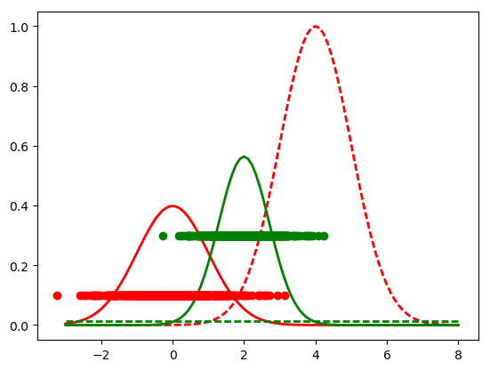

```
(0.014642532414232355,0.012951112459987962)
```

```julia
using PyPlot

N=500
x=randn(N)
xp=x/sqrt(2)+2

f=exp(-0.5(x-4).^2)
fp=exp(-0.5(xp-4).^2-0.5xp.^2+(xp-2).^2)/sqrt(2)

x0=linspace(-3,8,100)
f0=exp(-0.5(x0-4).^2)
fp0=exp(-0.5(x0-4).^2-0.5x0.^2+(x0-2).^2)/sqrt(2)
rho=exp(-x0.^2/2)/sqrt(2pi)
rho0=exp(-(x0-2).^2)/sqrt(pi)
plot(x0, f0, color="red", linewidth=2.0, linestyle="--")
plot(x0, rho, color="red", linewidth=2.0, linestyle="-")
plot(x0, fp0, color="green", linewidth=2.0, linestyle="--")
plot(x0, rho0, color="green", linewidth=2.0, linestyle="-")
plot(x,0.1ones(N),"ro")
plot(xp,0.3ones(N),"go")

(sum(f)/N,sum(fp)/N)
```

We are clearly wasting samples with DS.

Note one big problem with IS. In the real (multi-dimensional) cases we typically do not have a good guess for $\rho_0(x)$. One way of solving this problem is to search for good $\rho_0(x)$ adaptively. A sophisticated **adaptive** importance sampling package is available at https://pypi.python.org/pypi/pypmc/1.0.